[Edit this page](https://github.com/trafforddatalab/recipes/edit/master/gis/download_local_authority_boundaries.Rmd)

# Download local authority boundaries

The Office for National Statistics’ [Open Geography Portal](http://geoportal.statistics.gov.uk/) provide a range of geospatial datasets under the [Open Government Licence 3.0](https://www.nationalarchives.gov.uk/doc/open-government-licence/version/3). Digital vector boundaries for different administrative and statistical geographies are available to freely download. Here we’ll download a single local authority boundary file.

### Ingredients

**Data sources**

[ONS Open Geography Portal](https://geoportal.statistics.gov.uk/)

**R packages**

- [tidyverse](https://cran.r-project.org/web/packages/tidyverse/index.html)
- [sf](https://cran.r-project.org/web/packages/sf/index.html)

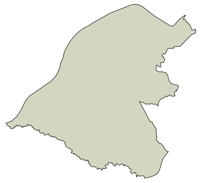

### Instructions

**Method 1: download all boundaries and filter in R**

1. Load the necessary R packages.

```r
library(tidyverse) ; library(sf)
```

2. Visit the [ONS Open Geography Portal](https://geoportal.statistics.gov.uk/) and select your local authority boundary: Boundaries > Administrative Boundaries > Local Authority Districts. For example, choose [Local Authority Districts (December 2018) Boundaries UK BGC](https://geoportal.statistics.gov.uk/datasets/local-authority-districts-december-2018-boundaries-uk-bgc) from the list.
3. Select the ‘APIs’ button on the right hand side and copy the URL path under GeoJSON.
4. Paste the URL into the dsn argument of `st_read()`.

```r
sf <- st_read("https://opendata.arcgis.com/datasets/2c5b8eb836c7475ba3b305106ac9dfc3_0.geojson")
```

5. Filter by your chosen local authority

```r
sf <- filter(sf, lad18nm == "Trafford")
```

6. Check the coordinate reference system

```r
st_crs(bdy)
```

7. Plot the results

```r
plot(st_geometry(sf))
```

8. Save the boundary as a GeoJSON

```r
st_write(sf, "local_authority_boundary.geojson")
```

**Method 2: filter using the API**

1. Load the necessary R packages.

```r
library(tidyverse) ; library(sf)
```

2. Visit the [ONS Open Geography Portal](https://geoportal.statistics.gov.uk/) and select your local authority boundary: Boundaries > Administrative Boundaries > Local Authority Districts. For example, choose [Local Authority Districts (December 2018) Boundaries UK BGC](https://geoportal.statistics.gov.uk/datasets/local-authority-districts-december-2018-boundaries-uk-bgc) from the list.
3. Select the ‘API Explorer’ button at the top of the page.
4. Navigate to the ‘Query’ box and click the **+** next to the ‘Where’ parameter. Select ‘lad18nm | Text’ from the ‘Attributes’ pick list and enter your local authority name in the box. Press Enter on your keyboard.
5. Highlight and copy the URL that appears in the ‘Query URL’ box.
6. Use the URL in the dsn argument of `st_read()` and retrieve the data.

```r
sf <- st_read("https://ons-inspire.esriuk.com/arcgis/rest/services/Administrative_Boundaries/Local_Authority_Districts_December_2018_Boundaries_GB_BGC/MapServer/0/query?where=UPPER(lad18nm)%20like%20'%25TRAFFORD%25'&outFields=lad18nm,long,lat,lad18cd&outSR=4326&f=json")
```

### Notes

Further information about using the Open Geography Portal API can be found [here](https://medium.com/@traffordDataLab/pushing-the-boundaries-with-the-open-geography-portal-api-4d70637bddc3).